# Generalized linear models

14 november 2014

## Chapter 7: Exercises

## Who will discuss function

```r
Choose <- function(n.names, replicate = 10000){
  names <- c("Lukas", "Roeline", "Zoë", "Lisanne", "Nigel", "Thijs")
  Who <- as.data.frame(matrix(NA, replicate))
  #pb <- txtProgressBar(min = 0, max = replicate, style = 3)
  for(i in 1:replicate){
    Who[i, ] <- sample(names, size = 1, replace=F)
    #setTxtProgressBar(pb, i)
  }
  #close(pb)
  nms <- sort(table(Who)/replicate, decreasing = T)[1:n.names]
  if(n.names == 2){
    cat(paste("Today's presenters are: \n",
              names(nms[1])," (",nms[1]," percent)", " and ",
              names(nms[2])," (",nms[2]," percent)", sep = ""))}
  else{print(nms)}
}
Choose(2)
```

```
## Today's presenters are:
## Lukas (0.1746 percent) and Nigel (0.1672 percent)
```

## Generalized linear models

## GLM's

We knew \[y=\alpha+\beta x+\epsilon\]

Now we consider \[\mathbb{E}[y] = \alpha + \beta x\]

They're the same. Different notation, different framework.

The upside is that we can now use a function for the expectation \(\mathbb{E}\) to allow for transformations. This would enable us to change \(\mathbb{E}[y]\) such that \(f(\mathbb{E}[y])\) has a linear relation with \(x\).

The function \(f()\) we call the `link function`. This function tranforms the scale of the response/outcome to the scale of the linear predictor.

Examples: \(f(x) = x, \\ f(x) = 1/x, \\ f(x) = \log(x), \\ f(x) = \log(x/(1-x)).\)

## Link functions

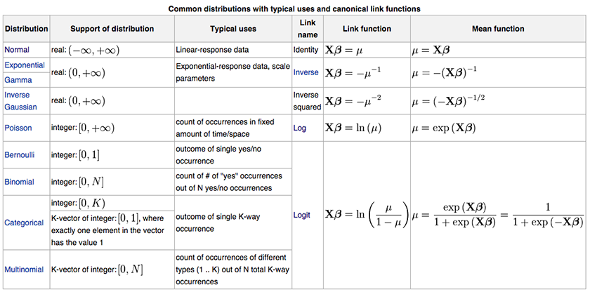

## GLM's continued

Remember that \[y=\alpha+\beta x+\epsilon,\]

and that \[\mathbb{E}[y] = \alpha + \beta x.\]

As a result \[y = \mathbb{E}[y] + \epsilon.\]

and residuals do not need to be normal (heck, \(y\) probably isn't, so why should \(\epsilon\) be?)

## Logit

\[\text{logit}(p) = \log(\frac{p}{1-p}) = \log(p) - \log(1-p)\]

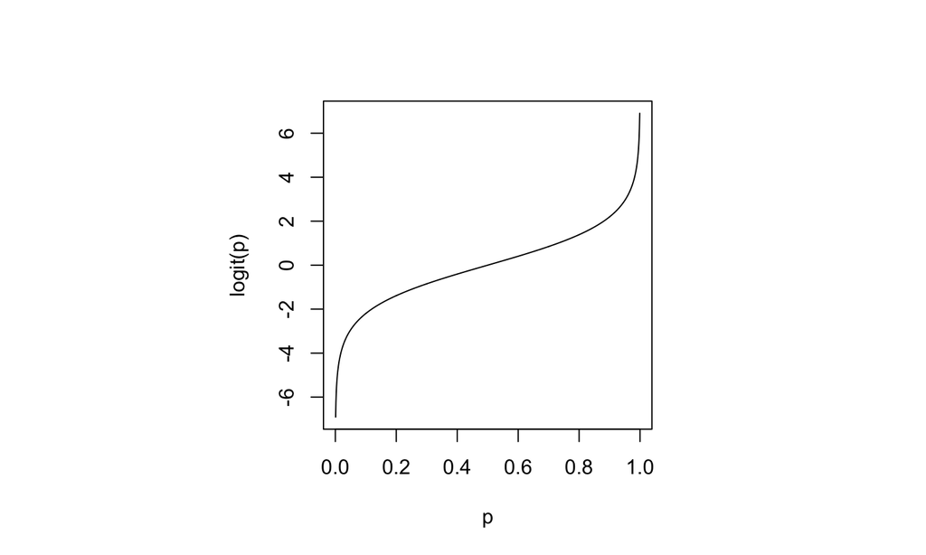

## Logit continued

Logit models work on the \(\log(\text{odds})\) scale

\[\log(\text{odds}) = \log(\frac{p}{1-p}) = \log(p) - \log(1-p) = \text{logit}(p)\]

The logit of the probability is the log of the odds.

Logistic regression allows us to model the \(\log(\text{odds})\) as a function of other, linear predictors.

## \(\log(\text{odds})\) explained

```r
logodds <- rep(NA, 1001)
for(i in 0:1000){p <- i/1000; logodds[i+1] <- log(p / (1-p))}
head(logodds)
```

```
## [1]      -Inf -6.906755 -6.212606 -5.806138 -5.517453 -5.293305
```

```r
tail(logodds)
```

```
## [1] 5.293305 5.517453 5.806138 6.212606 6.906755      Inf
```

## \(\log(\text{odds})\) explained

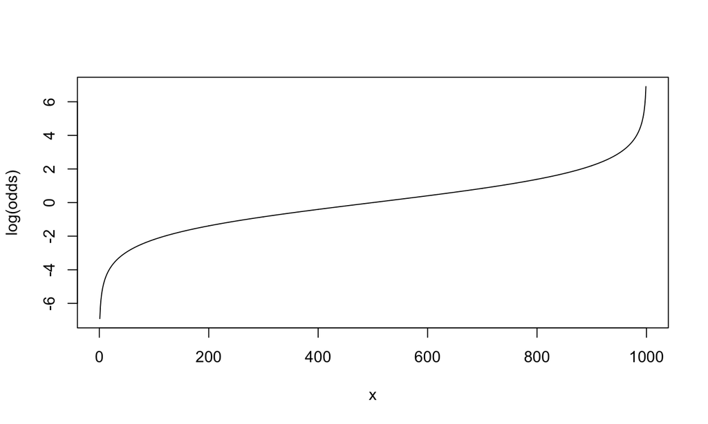

```r
plot(0:1000, logodds, xlab = "x", ylab = "log(odds)", type="l")
```

## logit\(^{-1}\) explained

```r
invlogit <- exp(logodds) / (1 + exp(logodds))
head(invlogit)
```

```
## [1] 0.000 0.001 0.002 0.003 0.004 0.005
```

```r
tail(invlogit)
```

```
## [1] 0.995 0.996 0.997 0.998 0.999   NaN
```

## logit\(^{-1}\) explained

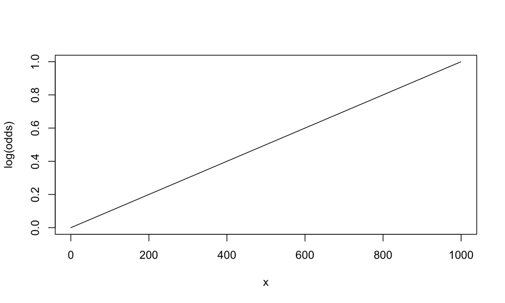

```r
plot(0:1000, invlogit, xlab = "x", ylab = "log(odds)", type="l")
```

## Logistic regression

## Logistic regression

With linear regression we had the `Sum of Squares (SS)`. Its logistic counterpart is the `Deviance (D)`.

With logistic regression we aim to maximize the `likelihood`, which is equivalent to minimizing the deviance.

The likelihood is the (joint) probability of the observed values, given the current model parameters.

In normally distributed data: \(\text{SS}=\text{D}\).

## Logistic regression

```r
library(DAAG)
anestot <- aggregate(anesthetic[, c("move","nomove")],
                     by=list(conc=anesthetic$conc), FUN=sum)
anestot$conc <- as.numeric(as.character(anestot$conc))
anestot$total <- apply(anestot[, c("move","nomove")], 1 , sum)
anestot$prop <- anestot$nomove/anestot$total
head(anestot)
```

```
##   conc move nomove total      prop
## 1  0.8    6      1     7 0.1428571
## 2  1.0    4      1     5 0.2000000
## 3  1.2    2      4     6 0.6666667
## 4  1.4    2      4     6 0.6666667
## 5  1.6    0      4     4 1.0000000
## 6  2.5    0      2     2 1.0000000
```

## Logistic regression

```r
glm(nomove ~ conc, family=binomial(link="logit"), data=anesthetic)
```

```
##
## Call:  glm(formula = nomove ~ conc, family = binomial(link = "logit"),
##     data = anesthetic)
##
## Coefficients:
## (Intercept)         conc
##      -6.469        5.567
##
## Degrees of Freedom: 29 Total (i.e. Null);  28 Residual
## Null Deviance:       41.46
## Residual Deviance: 27.75     AIC: 31.75
```

```r
glm(prop ~ conc, family=binomial(link="logit"), weights=total, data=anestot)$coef
```

```
## (Intercept)        conc
##   -6.468675    5.566762
```

## Logistic multiple regression

Always try to make the relation as linear as possible - after all you are assessing a linear model.

Do not forget that you use transformations to "make" things more linear

## Logistic multiple regression

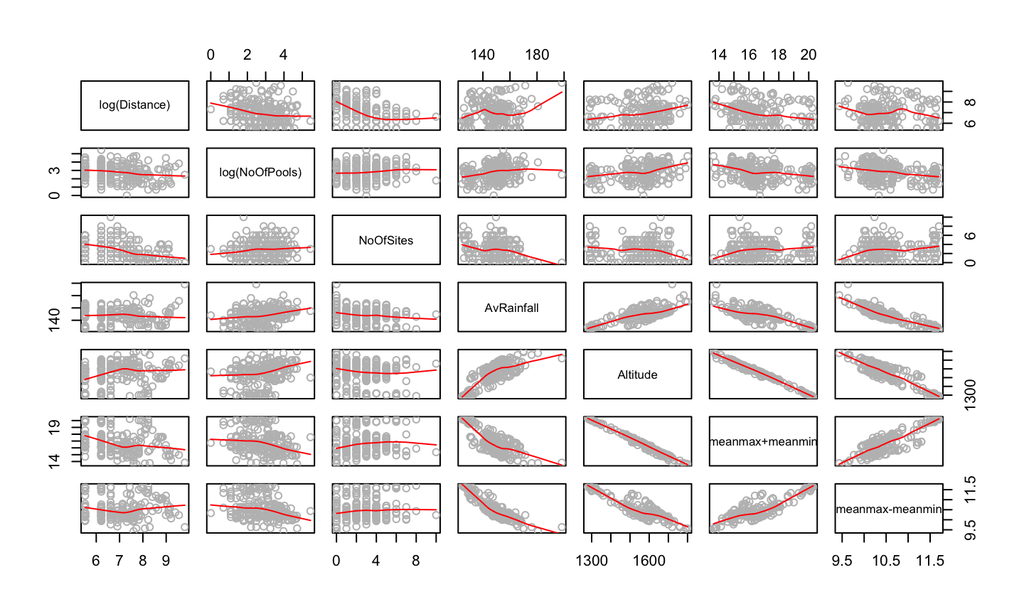

```r
with(frogs, pairs(cbind(log(distance), log(NoOfPools), NoOfSites, avrain, altitude, meanmax+meanmin, meanmax-meanmin), col="gray", panel=panel.smooth, labels=c("log(Distance)", "log(NoOfPools)", "NoOfSites", "AvRainfall", "Altitude", "meanmax+meanmin", "meanmax-meanmin")))
```

## Logistic multiple regression

```
##
## Call:
## glm(formula = pres.abs ~ log(distance) + log(NoOfPools) + NoOfSites +
##     avrain + I(meanmax + meanmin) + I(meanmax - meanmin), family = binomial,
##     data = frogs)
##
## Deviance Residuals:
##     Min       1Q   Median       3Q      Max
## -1.9763  -0.7189  -0.2786   0.7970   2.5745
##
## Coefficients:
##                        Estimate Std. Error z value Pr(>|z|)
## (Intercept)          18.2688999 16.1381912   1.132  0.25762
## log(distance)        -0.7583198  0.2558117  -2.964  0.00303 **
## log(NoOfPools)        0.5708953  0.2153335   2.651  0.00802 **
## NoOfSites            -0.0036201  0.1061469  -0.034  0.97279
## avrain                0.0007003  0.0411710   0.017  0.98643
## I(meanmax + meanmin)  1.4958055  0.3153152   4.744  2.1e-06 ***
## I(meanmax - meanmin) -3.8582668  1.2783921  -3.018  0.00254 **
## ---
## Signif. codes:  0 '***' 0.001 '**' 0.01 '*' 0.05 '.' 0.1 ' ' 1
##
## (Dispersion parameter for binomial family taken to be 1)
##
##     Null deviance: 279.99  on 211  degrees of freedom
## Residual deviance: 197.65  on 205  degrees of freedom
## AIC: 211.65
##
## Number of Fisher Scoring iterations: 5
```

## Logistic multiple regression

```
##
## Call:
## glm(formula = pres.abs ~ log(distance) + log(NoOfPools) + I(meanmax +
##     meanmin) + I(meanmax - meanmin), family = binomial, data = frogs)
##
## Deviance Residuals:
##     Min       1Q   Median       3Q      Max
## -1.9753  -0.7224  -0.2780   0.7974   2.5736
##
## Coefficients:
##                      Estimate Std. Error z value Pr(>|z|)
## (Intercept)           18.5268     5.2673   3.517 0.000436 ***
## log(distance)         -0.7547     0.2261  -3.338 0.000844 ***
## log(NoOfPools)         0.5707     0.2152   2.652 0.007999 **
## I(meanmax + meanmin)   1.4985     0.3088   4.853 1.22e-06 ***
## I(meanmax - meanmin)  -3.8806     0.9002  -4.311 1.63e-05 ***
## ---
## Signif. codes:  0 '***' 0.001 '**' 0.01 '*' 0.05 '.' 0.1 ' ' 1
##
## (Dispersion parameter for binomial family taken to be 1)
##
##     Null deviance: 279.99  on 211  degrees of freedom
## Residual deviance: 197.66  on 207  degrees of freedom
## AIC: 207.66
##
## Number of Fisher Scoring iterations: 5
```

## Fitted values

```r
head(fitted(frogs.glm))
```

```
##         2         3         4         5         6         7
## 0.9416691 0.9259228 0.9029415 0.8119619 0.9314070 0.7278038
```

```r
head(predict(frogs.glm, type="response"))
```

```
##         2         3         4         5         6         7
## 0.9416691 0.9259228 0.9029415 0.8119619 0.9314070 0.7278038
```

```r
head(predict(frogs.glm, type="link"))  # Scale of linear predictor
```

```
##         2         3         4         5         6         7
## 2.7815212 2.5256832 2.2303441 1.4628085 2.6085055 0.9835086
```

## Fitted values with approximate SE's

```r
pred <- predict(frogs.glm, type="link", se.fit=TRUE)
head(data.frame(fit = pred$fit, se = pred$se.fit))
```

```
##         fit        se
## 2 2.7815212 0.6859612
## 3 2.5256832 0.4851882
## 4 2.2303441 0.4381720
## 5 1.4628085 0.4805175
## 6 2.6085055 0.5290599
## 7 0.9835086 0.3900549
```

## Individual contributions

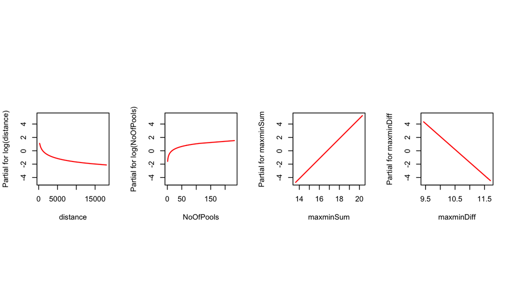

```r
par(mfrow=c(1,4), pty="s")
frogs$maxminSum <- with(frogs, meanmax+meanmin)
frogs$maxminDiff <- with(frogs, meanmax-meanmin)
frogs.glm <- glm(pres.abs ~ log(distance) + log(NoOfPools) +
                 maxminSum + maxminDiff, family = binomial,
                 data = frogs)
termplot(frogs.glm)
```

## Cross validating predictive power

```r
frogs.glm <- glm(pres.abs ~ log(distance) + log(NoOfPools),
                 family=binomial,data=frogs)
cv <- CVbinary(frogs.glm)
```

```
##
## Fold:  5 7 3 1 9 8 6 2 10 4
## Internal estimate of accuracy = 0.759
## Cross-validation estimate of accuracy = 0.745
```

```r
ls(cv)
```

```
## [1] "acc.cv"       "acc.internal" "acc.training" "cvhat"
## [5] "internal"     "training"
```

## Logistic models for categorical data

## Loglinear model

```r
str(UCBAdmissions)
```

```
##  table [1:2, 1:2, 1:6] 512 313 89 19 353 207 17 8 120 205 ...
##  - attr(*, "dimnames")=List of 3
##   ..$ Admit : chr [1:2] "Admitted" "Rejected"
##   ..$ Gender: chr [1:2] "Male" "Female"
##   ..$ Dept  : chr [1:6] "A" "B" "C" "D" ...
```

```r
UCBAdmissions
```

```
## , , Dept = A
##
##           Gender
## Admit      Male Female
##   Admitted  512     89
##   Rejected  313     19
##
## , , Dept = B
##
##           Gender
## Admit      Male Female
##   Admitted  353     17
##   Rejected  207      8
##
## , , Dept = C
##
##           Gender
## Admit      Male Female
##   Admitted  120    202
##   Rejected  205    391
##
## , , Dept = D
##
##           Gender
## Admit      Male Female
##   Admitted  138    131
##   Rejected  279    244
##
## , , Dept = E
##
##           Gender
## Admit      Male Female
##   Admitted   53     94
##   Rejected  138    299
##
## , , Dept = F
##
##           Gender
## Admit      Male Female
##   Admitted   22     24
##   Rejected  351    317
```

## Loglinear model

```r
dimnames(UCBAdmissions)  # Check levels of table margins
```

```
## $Admit
## [1] "Admitted" "Rejected"
##
## $Gender
## [1] "Male"   "Female"
##
## $Dept
## [1] "A" "B" "C" "D" "E" "F"
```

```r
UCB <- as.data.frame.table(UCBAdmissions["Admitted", , ])
names(UCB)[3] <- "admit"
UCB$reject <- as.data.frame.table(UCBAdmissions["Rejected", , ])$Freq
UCB$Gender <- relevel(UCB$Gender, ref="Male")
## Add further columns total and p (proportion admitted)
UCB$total <- UCB$admit + UCB$reject
UCB$p <- UCB$admit/UCB$total
```

## Loglinear model

```r
UCB
```

```
##    Gender Dept admit reject total          p
## 1    Male    A   512    313   825 0.62060606
## 2  Female    A    89     19   108 0.82407407
## 3    Male    B   353    207   560 0.63035714
## 4  Female    B    17      8    25 0.68000000
## 5    Male    C   120    205   325 0.36923077
## 6  Female    C   202    391   593 0.34064081
## 7    Male    D   138    279   417 0.33093525
## 8  Female    D   131    244   375 0.34933333
## 9    Male    E    53    138   191 0.27748691
## 10 Female    E    94    299   393 0.23918575
## 11   Male    F    22    351   373 0.05898123
## 12 Female    F    24    317   341 0.07038123
```

## loglinear model

```r
UCB.glm <- glm(p ~ Dept*Gender, family=binomial,
               data=UCB, weights=total)
anova(UCB.glm, test="Chisq")
```

```
## Analysis of Deviance Table
##
## Model: binomial, link: logit
##
## Response: p
##
## Terms added sequentially (first to last)
##
##
##             Df Deviance Resid. Df Resid. Dev  Pr(>Chi)
## NULL                           11     877.06
## Dept         5   855.32         6      21.74 < 2.2e-16 ***
## Gender       1     1.53         5      20.20  0.215928
## Dept:Gender  5    20.20         0       0.00  0.001144 **
## ---
## Signif. codes:  0 '***' 0.001 '**' 0.01 '*' 0.05 '.' 0.1 ' ' 1
```

## loglinear model

```r
summary(UCB.glm)$coef
```

```
##                       Estimate Std. Error     z value     Pr(>|z|)
## (Intercept)         0.49212143 0.07174966   6.8588682 6.940825e-12
## DeptB               0.04162783 0.11318919   0.3677721 7.130431e-01
## DeptC              -1.02763967 0.13549685  -7.5842331 3.344593e-14
## DeptD              -1.19607953 0.12640656  -9.4621632 3.016374e-21
## DeptE              -1.44908321 0.17681152  -8.1956378 2.492678e-16
## DeptF              -3.26186520 0.23119594 -14.1086615 3.358928e-45
## GenderFemale        1.05207596 0.26270810   4.0047336 6.208742e-05
## DeptB:GenderFemale -0.83205342 0.51039480  -1.6302153 1.030560e-01
## DeptC:GenderFemale -1.17699758 0.29955796  -3.9291147 8.525915e-05
## DeptD:GenderFemale -0.97008876 0.30261874  -3.2056467 1.347593e-03
## DeptE:GenderFemale -1.25226298 0.33032201  -3.7910371 1.500195e-04
## DeptF:GenderFemale -0.86318013 0.40266653  -2.1436600 3.206014e-02
```

The first six regression coefficients give the \(\log(\text{odds})\) for males.

## Poisson regression

```r
ACF1
```

```
##    count endtime
## 1      1       6
## 2      3       6
## 3      5       6
## 4      1       6
## 5      2       6
## 6      1       6
## 7      1       6
## 8      3      12
## 9      1      12
## 10     2      12
## 11     6      12
## 12     0      12
## 13     0      12
## 14     4      12
## 15     1      12
## 16    10      18
## 17     6      18
## 18     6      18
## 19     7      18
## 20     5      18
## 21     7      18
## 22     6      18
```

## Poisson regression

```r
summary(ACF.glm <- glm(formula = count ~ endtime, family = poisson, data = ACF1))
```

```
##
## Call:
## glm(formula = count ~ endtime, family = poisson, data = ACF1)
##
## Deviance Residuals:
##      Min        1Q    Median        3Q       Max
## -2.46204  -0.47851  -0.07943   0.38159   2.26332
##
## Coefficients:
##             Estimate Std. Error z value Pr(>|z|)
## (Intercept) -0.32152    0.40046  -0.803    0.422
## endtime      0.11920    0.02642   4.511 6.44e-06 ***
## ---
## Signif. codes:  0 '***' 0.001 '**' 0.01 '*' 0.05 '.' 0.1 ' ' 1
##
## (Dispersion parameter for poisson family taken to be 1)
##
##     Null deviance: 51.105  on 21  degrees of freedom
## Residual deviance: 28.369  on 20  degrees of freedom
## AIC: 92.209
##
## Number of Fisher Scoring iterations: 5
```

## Poisson regression: fitted values

```r
fitted(ACF.glm)
```

```
##        1        2        3        4        5        6        7        8
## 1.482388 1.482388 1.482388 1.482388 1.482388 1.482388 1.482388 3.030821
##        9       10       11       12       13       14       15       16
## 3.030821 3.030821 3.030821 3.030821 3.030821 3.030821 3.030821 6.196674
##       17       18       19       20       21       22
## 6.196674 6.196674 6.196674 6.196674 6.196674 6.196674
```

## Quasi-likelihood

A quasi-likelihood function has similar properties to the log-likelihood function

```
- a quasi-likelihood function is not the log-likelihood
- it does not correspond to any actual probability distribution.
```

Used to allow for overdispersion during estimation

```
- Overdispersion occurs when there is greater variability in the data than would be expected from

the statistical model that is used.
```

## Quasi-poisson regression

```r
summary(glm(formula = count ~ endtime, family = quasipoisson, data = ACF1))
```

```
##
## Call:
## glm(formula = count ~ endtime, family = quasipoisson, data = ACF1)
##
## Deviance Residuals:
##      Min        1Q    Median        3Q       Max
## -2.46204  -0.47851  -0.07943   0.38159   2.26332
##
## Coefficients:
##             Estimate Std. Error t value Pr(>|t|)
## (Intercept) -0.32152    0.45532  -0.706 0.488239
## endtime      0.11920    0.03004   3.968 0.000758 ***
## ---
## Signif. codes:  0 '***' 0.001 '**' 0.01 '*' 0.05 '.' 0.1 ' ' 1
##
## (Dispersion parameter for quasipoisson family taken to be 1.292733)
##
##     Null deviance: 51.105  on 21  degrees of freedom
## Residual deviance: 28.369  on 20  degrees of freedom
## AIC: NA
##
## Number of Fisher Scoring iterations: 5
```

## Transformations

## \(y=\sqrt{n}\)

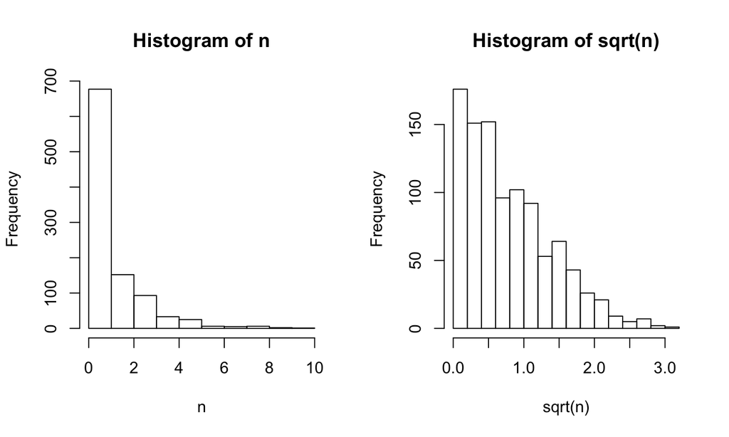

```r
n <- rnorm(1000, 0, 1)^2
par(mfrow = c(1,2))
hist(n)
hist(sqrt(n))
```

## \(y=\text{arcsin}(\sqrt{p})\)

Used to linearize sigmoid distributions and to equalize variances of proportions.

```r
p <- seq(.1:1, by = .1)
p
```

```
##  [1] 0.1 0.2 0.3 0.4 0.5 0.6 0.7 0.8 0.9 1.0
```

```r
asin(sqrt(p))
```

```
##  [1] 0.3217506 0.4636476 0.5796397 0.6847192 0.7853982 0.8860771 0.9911566
##  [8] 1.1071487 1.2490458 1.5707963
```

```r
asin(sqrt(p)) * 180/pi
```

```
##  [1] 18.43495 26.56505 33.21091 39.23152 45.00000 50.76848 56.78909
##  [8] 63.43495 71.56505 90.00000
```

## Next session

Prepare for next session:

- Exercises Chapter 8
  - 1, 2, 3 and 4
- Study the reading material and exercises from Chapters 6, 7 and 8.